# Metheorogical Events across US and its effects

R3M79

08/12/2017

# Synopsis

The purpose of this analysis to answer the following questions:

1. Across the United States, which types of events are most harmful with respect to population health?
2. Across the United States, which types of events have the greatest economic consequences?

The analysis was performed by using the data provided by the U.S. National Oceanic and Atmospheric Administration’s (NOAA) storm database. For our analysis we limited the results to the top 10 most relevant for each question.

## Data Processing

The data used on this analysis was downloaded from the following link: https://d396qusza40orc.cloudfront.net/repdata%2Fdata%2FStormData.csv.bz2

### Loading and preprocessing the data

```r
#load libraries
library(dplyr)
library(ggplot2)

#check if file exists
dataFile<-dir(pattern="*.bz2")
if (!file.exists(dataFile)) {
    stop("Dataset file not present!")
}

#load storm data
stormSet<-read.csv(dataFile)
```

Prepare and process Data for Question 1.

- Results will be limited to top 10 most harmfull events
- Two temporary datasets will be created (one for fatalities and other for injuries) with the following columns:
  - EventType: Type of Weather Event
  - Count: Total of fatalities/injuries
  - EffectType: indicates if values refer Fatalities or Injuries
- A dataset will be created as the merge from the temporary datasets

```r
# Prepare data to answer question 1:
# Results will be limited to top 10 most harmfull events

#create dataset with only one column for fatalities and injuries count

#dataset for fatalities only
stormSetFatalities<-stormSet[stormSet$FATALITIES>0,c("STATE","EVTYPE","FATALITIES")]
stormSetFatalities$EFFTYPE<-"Fatalities"
names(stormSetFatalities)<-c("State","EventType","Count","EffectType")
stormSetFatalitiesFinal <- stormSetFatalities %>%
    group_by(EventType,EffectType) %>%
    summarize(Count = sum(Count)) %>%
    as.data.frame()

#sort data by count and store top 10
stormSetFatalitiesFinal<- head(stormSetFatalitiesFinal[order(as.numeric(-stormSetFatalitiesFinal[,"Count"])),],10)

#dataset for injuries only
stormSetInjuries<-stormSet[stormSet$INJURIES>0,c("STATE","EVTYPE","INJURIES")]
stormSetInjuries$EFFTYPE<-"Injuries"
names(stormSetInjuries)<-c("State","EventType","Count","EffectType")
stormSetInjuriesFinal <- stormSetInjuries %>%
    group_by(EventType,EffectType) %>%
    summarize(Count = sum(Count)) %>%
    as.data.frame()

#sort data by count and store top 10
stormSetInjuriesFinal<- head(stormSetInjuriesFinal[order(as.numeric(-stormSetInjuriesFinal[,"Count"])),],10)


#merge both objects
stormSetHealthEffects<-rbind(stormSetFatalitiesFinal,stormSetInjuriesFinal)

#clear temporary objects
rm(stormSetFatalities,stormSetInjuries,stormSetFatalitiesFinal,stormSetInjuriesFinal)
```

Prepare and process Data for Question 2.

A function must be created to convert symbols (B,M,K,H) from columns PROPDMGEXP and CROPDMGEXP to the corresponding exponent value

```r
#convert exponent multipliers
convUnit<-function(x){
    expUnit <- 0 # default value
    expUnit <- ifelse(toupper(x) == "B",9,expUnit)
    expUnit <- ifelse(toupper(x) == "M",6,expUnit)
    expUnit <- ifelse(toupper(x) == "K",3,expUnit)
    expUnit <- ifelse(toupper(x) == "H",2,expUnit)

    return(as.numeric(expUnit))
}
```

```r
#dataset for property damage
stormSetDamageProp<-stormSet[,c("EVTYPE","PROPDMG","PROPDMGEXP")] %>%
    mutate(TOTALPROPDMG = PROPDMG * (10^convUnit(PROPDMGEXP))) %>%
    group_by(EVTYPE) %>%
    summarize(Count = sum(TOTALPROPDMG)) %>%
    as.data.frame()

names(stormSetDamageProp)<-c("EventType","TotalDamage")
stormSetDamageProp$DamageType <- "Property Damages"

#sort data by count and store top 10
stormSetDamageProp<- head(stormSetDamageProp[order(as.numeric(-stormSetDamageProp[,"TotalDamage"])),],10)


stormSetDamageCrop<-stormSet[,c("EVTYPE","CROPDMG","CROPDMGEXP")] %>%
    mutate(TOTALCROPDMG = CROPDMG * (10^convUnit(CROPDMGEXP))) %>%
    group_by(EVTYPE) %>%
    summarize(Count = sum(TOTALCROPDMG)) %>%
    as.data.frame()

names(stormSetDamageCrop)<-c("EventType", "TotalDamage")
stormSetDamageCrop$DamageType <- "Crop Damages"

#sort data by count and store top 10
stormSetDamageCrop<- head(stormSetDamageCrop[order(as.numeric(-stormSetDamageCrop[,"TotalDamage"])),],10)


#merge both objects
stormSetDamageFinal<-rbind(stormSetDamageProp,stormSetDamageCrop)

#clear temporary objects
rm(stormSetDamageProp,stormSetDamageCrop)
```

## Results

Using the datasets created in the Data Processing Section, the results will be presented in this section

### Results for question 1

Plot will be generated using dataset stormSetHealthEffects

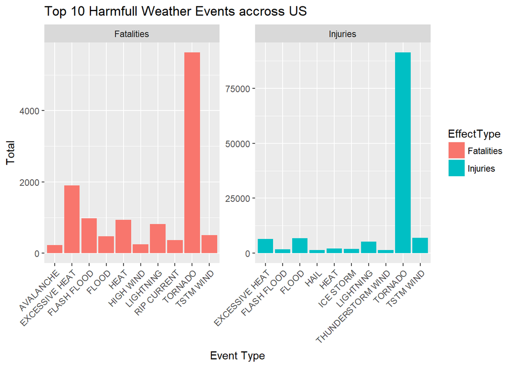

```r
stormHealthEffectsPlot <-ggplot(stormSetHealthEffects, aes(EventType,Count,
                                                           fill=EffectType))
stormHealthEffectsPlot + labs(x="Event Type",y ="Total",
                              title ="Top 10 Harmfull Weather Events accross US") +
    geom_bar(stat="identity", position="dodge") +
    theme(axis.text.x = element_text(angle = 45, hjust = 1)) +
    facet_wrap(~EffectType,scales = "free")
```

### Results for question 2

Plot will be generated using dataset stormSetDamageFinal

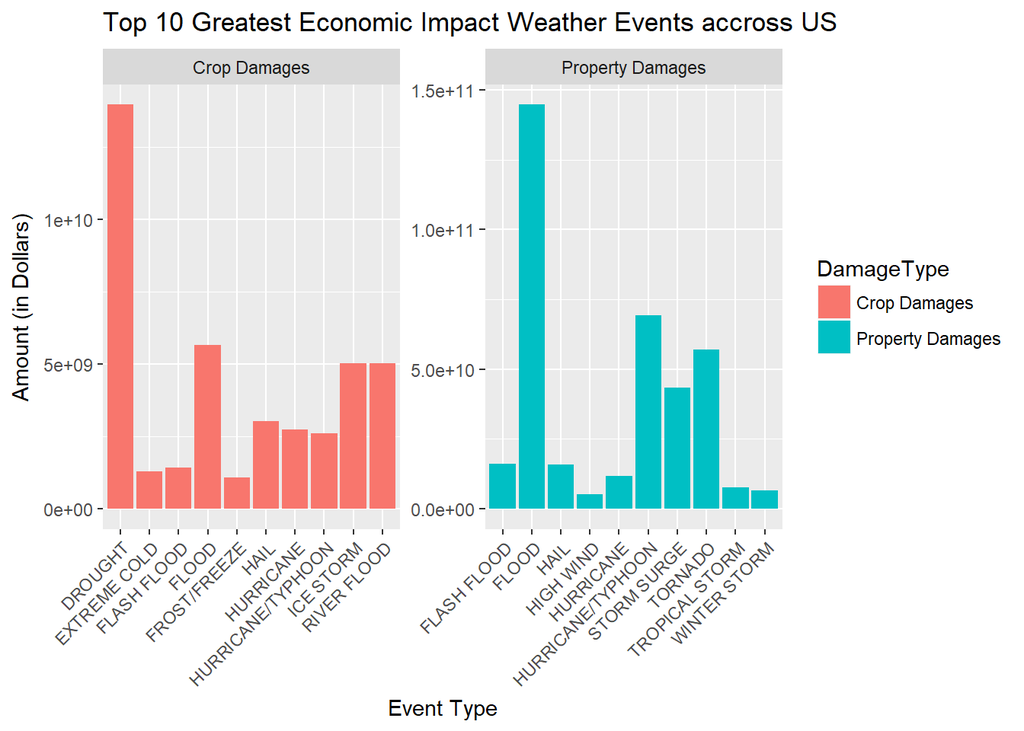

```r
stormSetDamagePlot <-ggplot(stormSetDamageFinal, aes(EventType,TotalDamage,
                                                           fill=DamageType))
stormSetDamagePlot + labs(x="Event Type",y ="Amount (in Dollars)",
                              title ="Top 10 Greatest Economic Impact Weather Events accross US") +
    geom_bar(stat="identity", position="dodge") +
    theme(axis.text.x = element_text(angle = 45, hjust = 1)) +
    facet_wrap(~DamageType,scales = "free")
```